# SPARK: A Continuous-Time Phase-Domain State-Space Framework for Reconstructing Cardiac Autonomic Dynamics from Heartbeat Intervals

Authors

Affiliations

Matías Castillo-Aguilar

Escuela de Medicina, Universidad de Magallanes, Punta Arenas, Chile.

Noah Beelders

Department of Mathematics, University of Munich, Theresienstraße 39, 80333 Munich, Germany.

Diego Mabe-Castro

Escuela de Medicina, Universidad de Magallanes, Punta Arenas, Chile.

Cristian Núñez-Espinosa

Escuela de Medicina, Universidad de Magallanes, Punta Arenas, Chile.

Published

July 7, 2026

Code Links

Model (R script)

**Highlights**

- A phase-domain reformulation converts cardiac first-passage inference into a conditionally linear-Gaussian state-space problem.
- Continuous-time autonomic dynamics are propagated analytically across irregular heartbeat intervals.
- Joint estimation separates latent autonomic kinetics while preserving continuous physiological trajectories.
- State-dependent variability emerges naturally from the underlying point-process formulation.
- The framework provides a continuous-time basis for mechanistic studies of cardiac autonomic regulation.

**Abstract**

Heart rate variability provides a non-invasive window into cardiac autonomic regulation, yet existing approaches rely primarily on descriptive signal-processing metrics or discrete-time point-process models that provide limited access to the underlying continuous physiological dynamics. Recovering latent autonomic activity from irregular heartbeat intervals remains challenging because cardiac pacing is naturally formulated as a stochastic first-passage problem, leading to nonlinear observation models that require approximate inference. We introduce SPARK (Stochastic Phase-domain Autonomic Reconstruction Kinetics), a continuous-time stochastic differential equation framework that reformulates cardiac point-process inference in the phase domain. Conditioning on the observed heartbeat interval transforms the nonlinear first-passage problem into a conditionally linear-Gaussian state-space model, enabling continuous-time estimation with standard linear filtering. Sympathetic and parasympathetic regulation are represented as independent Ornstein–Uhlenbeck processes propagated analytically across irregular sampling intervals, while likelihood profiling and wavelet-informed regularization ensure identifiable physiological parameters. The framework was evaluated using resting, orthostatic, and exercise-recovery datasets spanning stationary and strongly non-stationary autonomic conditions. It accurately reconstructed heartbeat intervals, satisfied point-process goodness-of-fit diagnostics, recovered biologically plausible sympathetic and parasympathetic kinetics, and continuously tracked autonomic state trajectories during rapid physiological transitions. By reformulating cardiac point-process estimation as a continuous-time state-space problem, SPARK provides a mechanistically interpretable framework for reconstructing latent autonomic dynamics directly from heartbeat intervals. This approach extends conventional heart rate variability analysis and establishes a foundation for continuous-time physiological system identification and future studies of autonomic regulation as a stochastic dynamical system

**Keywords**: Stochastic Differential Equations, Point-Process Modeling, First-Passage Time, State-Space Estimation, Autonomic Nervous System, Phase-Space Topology, Heart Rate Variability, Non-Equilibrium Thermodynamics

# 1 Introduction

The pacing of the mammalian heart is governed by the autonomic nervous system. The sinoatrial node acts as the primary chronotropic interface, translating continuous neural efferent traffic into a sequence of discrete cardiac contractions (Kashou, Basit, and Chhabra 2017; Hennis et al. 2024). This regulatory control relies on the reciprocal modulation of the parasympathetic and sympathetic branches. Parasympathetic signaling, mediated by acetylcholine release, rapidly hyperpolarizes pacemaker cells to decelerate the firing rate (Maltsev et al. 2023; Varzideh et al. 2026). Sympathetic signaling, mediated by norepinephrine cascades, slowly depolarizes the cells to accelerate pacing (Hennis et al. 2024; H. Liu, Cao, and Su 2026). The macroscopic observation of these competing microscopic forces is a temporal sequence of inter-beat intervals (Maltsev et al. 2023). Understanding the continuous dynamics of these unobserved neural branches from the discrete interval sequence is a central objective of cardiovascular physics (Saul and Valenza 2021; Rosas et al. 2024). Because direct microneurographic measurement of cardiac efferent nerve activity is highly invasive and technically constrained, inference relies entirely upon non-invasive mathematical frameworks (Verma et al. 2023; Rahman et al. 2025).

Historically, the analysis of heart rate variability has provided the standard non-invasive proxy for autonomic regulation (Saul and Valenza 2021; S. Liu, Cui, and Chen 2025). This methodology relies upon phenomenological signal processing, segmenting the interval sequence into time-domain statistical variances and frequency-domain spectral transformations (Arya, Singh, and Singh 2024; S. Liu, Cui, and Chen 2025). These metrics provide descriptive summaries but possess severe theoretical limitations. Standard frequency-domain partitioning assumes underlying signal stationarity, an assumption violated by biological systems responding to transient environmental perturbations (Kim, Seok, and Shin 2021; Saul and Valenza 2021). Furthermore, classical spectral bands fail to isolate the true underlying physiological drivers (S. Liu, Cui, and Chen 2025). High-frequency variance represents parasympathetic respiratory coupling, but the low-frequency component remains a confounded amalgamation of sympathetic activity, vagal modulation, and mechanical baroreflex feedback (Moak et al. 2007; S. Liu, Cui, and Chen 2025). Phenomenological descriptors measure the geometric shape of the output data but cannot model the generative biophysics of the cellular pacemaker (Saul and Valenza 2021).

To bridge the gap between macroscopic observation and microscopic physiology, research must transition toward generative architectures (Rosas et al. 2024; Yang et al. 2023). The biophysical reality of the sinoatrial node is an integrate-and-fire oscillator (Yang et al. 2023; Maltsev et al. 2023). Pacemaker cells accumulate a physiological phase over time, driven by an intrinsic depolarization rate modulated by autonomic inputs (Hennis et al. 2024; H. Liu, Cao, and Su 2026). A cardiac contraction is triggered the moment this accumulated phase reaches a deterministic threshold (Maltsev et al. 2023). This continuous-time accumulation, terminating in a discrete event, defines the Integral Pulse Frequency Modulation framework (Candia-Rivera et al. 2021; Adamczyk and Polak 2025). When modeled as a stochastic drift-diffusion process, the time elapsed between boundary crossings follows an Inverse Gaussian distribution (Barbieri et al. 2005; Lin and Wang 2026). This distribution captures the positive, right-skewed morphology of heartbeat intervals. However, standard implementations treat the distribution parameters as static constants rather than dynamic consequences of continuous neural control (Rosas et al. 2024).

Embedding the continuous integrate-and-fire oscillator within a dynamic state-space formulation introduces a structural and operational bottleneck (Rosas et al. 2024). Extracting the continuous latent autonomic drift from the discrete sequence of intervals requires solving the boundary-crossing problem of a stochastic differential equation (Rosas et al. 2024). In standard estimation architectures, predicting the precise moment a random variable will hit a fixed boundary constitutes a nonlinear first-passage time problem. Traditional filtering approaches attempt to solve this by imposing local linearizations (e.g., Extended Kalman Filters), evaluating discrete time steps through Euler-Maruyama approximations, or deploying deterministic sampling matrices (e.g., Unscented Kalman Filters) (Rosas et al. 2024). Furthermore, while contemporary deep learning architectures excel at phenomenological pattern recognition in inter-beat intervals, their latent representations lack physiological interpretability and cannot extract the explicit, continuous-time biophysical kinetic parameters required for mechanistic clinical interpretation. Consequently, both standard approximations and deep learning models inherently distort or obscure the continuous-time point-process dynamics (Rosas et al. 2024). The disconnect between continuous integration and discrete observation introduces computational overhead and geometric instability, making the simultaneous optimization of multiple continuous-time parameters intractable (Rosas et al. 2024).

The classical approach treats the elapsed time as a random variable evaluated against a fixed phase boundary, making the non‑linearities of the first‑passage time unavoidable (Barbieri et al. 2005; Rosas et al. 2024). The present manuscript introduces a structural inversion of this relationship. Rather than treating time as the random variable, we treat the recorded RR interval as a deterministic observation window and ask what physiological condition must hold at its end. By definition, a heartbeat marks the moment when the sinoatrial phase reaches the threshold (Maltsev et al. 2023). Under the physiological condition that the depolarization drift is large relative to intrinsic noise, the probability of the phase having crossed threshold and returned during a single interval is negligible (Reith-Braun et al. 2023). Hence, the strict first‑passage condition can be replaced by the terminal‑threshold condition: a beat observed at time implies that the accumulated phase over the window equals one. Because a drift‑diffusion process evaluated over a fixed, deterministic window is linear and Gaussian, this coordinate inversion yields an exact, conditionally Gaussian measurement equation (Hughes et al. 2017). The observation is linear in the time‑integrals of the autonomic states, enabling closed-form linear estimation theory without approximation (Särkkä and Garcı́a-Fernández 2020).

To exploit this linear observation geometry, the latent state-space must be augmented. The continuous autonomic drivers are modeled as independent, mean-reverting Ornstein-Uhlenbeck processes, representing the biological tendency of the neural branches to return to homeostatic baselines following transient stimuli (Garcı́a Fernández, Ahmad, and Van Gerven 2024; Hennis et al. 2024). By expanding the state vector to continuously track the running integrals of these autonomic tones alongside their instantaneous values, the phase-domain observation equation reduces to a sparse linear combination. Because the underlying stochastic differential equations are linear, the discrete-time transitions across uneven sampling intervals can be solved analytically via the matrix exponential. This framework evaluates the continuous-time transitions analytically, avoiding numerical approximations. The integral states and their associated covariances are deterministically reset to zero following each measurement update, preserving the uncoupled physiological geometry of the cellular reset mechanism.

While the augmented linear-Gaussian formulation resolves the nonlinear filtering bottleneck, evaluating the state-space introduces a dimensional hyperparameter space. Extracting distinct sympathetic and parasympathetic kinetics from a single macroscopic sequence of intervals is an underdetermined inverse problem (Candia-Rivera, Vico Fallani, and Chavez 2025). Unconstrained maximum likelihood estimation applied to this space yields degenerate parameter ridges, scaling ambiguities, and frequency blending (Candia-Rivera, Vico Fallani, and Chavez 2025). Attempting to optimize the physiological clearance rates, baseline intrinsic drift, system volatilities, and observation noise simultaneously results in numerical instability and parameter non-identifiability. The framework presented addresses this dimensional collapse by enforcing deterministic constraints and mathematical marginalization.

Because the proposed observation equation is linear with respect to the continuous pacing integrals, the optimization topology can be analytically reduced. The present methodology implements a dual-filter generalized least squares architecture to analytically marginalize the baseline intrinsic drift from the likelihood equation. The global system volatility is similarly extracted via concentrated root-finding. By integrating out these dimensions, the optimization is restricted purely to the structural kinetics of the neural branches. To establish absolute identifiability between the superimposed parasympathetic and sympathetic drives, we anchor the fractional variance of the neural branches deterministically. Using Parseval’s theorem, the continuous frequency-domain energy of the macroscopic signal is mapped directly to the time-domain variance of the underlying differential equations (Govil, Yao, and Borao 2024). Finally, the physiological reality of rapid vagal neurotransmission and slow sympathetic clearance is enforced via strict bounded probability priors (Hennis et al. 2024; Maltsev et al. 2023). To resolve these structural limitations, we introduce the SPARK (Stochastic Phase-domain Autonomic Reconstruction Kinetics) framework. Through structural coordinate inversion, analytical marginalization, and deterministic spectral anchoring, the SPARK architecture provides a complete solution for extracting latent autonomic kinetics directly from discrete cardiac observations.

# 2 Methods

## 2.1 Model formulation

### 2.1.1 The first-passage time formulation of cardiac pacing

In cardiovascular physics, the series of time intervals between successive heartbeats is treated as a sequence of discrete events generated by an underlying continuous physiological mechanism. Traditional point-process frameworks analyze the generation of these events through the Integral Pulse Frequency Modulation model. This model posits that the sinoatrial node acts as an integrate-and-fire oscillator. The pacemaker cells continuously accumulate a physiological phase over time, driven by an intrinsic depolarization rate that is modulated by the autonomic nervous system. A cardiac contraction is triggered at the moment this accumulated phase reaches a specific deterministic threshold.

Let the instantaneous phase of the sinoatrial node be defined as $\phi(t)$, initiating at $\phi(0) = 0$ following the previous heartbeat. The continuous-time evolution of this phase is governed by a drift-diffusion stochastic differential equation, representing the physical Wiener process occurring at the cellular level:

$$d\phi(t) = \nu(t) dt + \sigma_z dW(t)$$

In this system, $\nu(t)$ represents the continuous net drift rate, which corresponds to the pacemaker firing frequency determined by the balance of autonomic inputs. The diffusion coefficient $\sigma_z$ accounts for the intrinsic thermodynamic white noise and local cellular refractoriness at the sinoatrial node, while $W(t)$ denotes a standard one-dimensional Brownian motion. By normalizing the physiological depolarization threshold to represent one complete cardiac cycle, such that the threshold equals $1.0$, the observed duration of a heartbeat interval becomes a random variable. Specifically, the observed interval $T$ is the first-passage time of the Wiener process crossing the absorbing boundary:

$$T = \inf \{ t > 0 : \phi(t) \ge 1.0 \}$$

Solving the boundary-crossing problem for this stochastic process yields a probability density function for the time interval $T$ that follows an Inverse Gaussian distribution. While the Inverse Gaussian formulation accurately captures the positive, right-skewed morphology characteristic of heartbeat intervals, estimating the latent drift $\nu(t)$ from this time-domain distribution introduces severe mathematical bottlenecks. When embedded within a state-space architecture, predicting the moment a stochastic boundary will be crossed constitutes a highly nonlinear estimation problem. Standard approaches force the use of local linearizations, such as the Extended Kalman Filter, or deterministic sampling techniques, such as the Unscented Kalman Filter. These discrete-time approximations inherently distort the continuous-time point-process dynamics and introduce significant computational overhead, making the simultaneous optimization of multiple physiological parameters geometrically unstable.

### 2.1.2 Phase-domain inversion and observation linearity

To bypass the mathematical nonlinearities inherent in evaluating stochastic first-passage times, we introduce an isomorphic coordinate mapping. The computational limitations of classical point-process architectures stem directly from treating the event duration $T$ as a free random variable evaluated against an absorbing phase boundary. We invert this analytical dependency. Rather than evaluating the stochastic boundary-crossing time over a fixed phase space, we condition the system on the observed, deterministic event window to analytically evaluate the latent phase accumulated at the terminal boundary.

Consequently, we formulate an equivalent terminal-threshold model: a cardiac contraction implies precisely that the accumulated phase has reached unity at the conclusion of the observed interval $\Delta t_k$. For high-drift, low-noise biological regimes, this formulation converges asymptotically with the strict first-passage time process (see the formal proof in the “Asymptotic convergence of the phase-domain mapping” section in the supplementary material).

The recorded duration between two consecutive heartbeats, $\Delta t_k$, is treated as a fixed, observed quantity. To evaluate the accumulated phase, we integrate the foundational drift-diffusion stochastic differential equation over this deterministic temporal window, $[t_{k-1}, t_k]$:

$$\int_{t_{k-1}}^{t_k} d\phi(t) = \int_{t_{k-1}}^{t_k} \nu(t) dt + \int_{t_{k-1}}^{t_k} \sigma_z dW(t)$$

At the trigger of a heartbeat, the accumulated phase must reach the normalized threshold, making the left side of the equation equal to $1.0$. By the fundamental properties of the continuous Wiener process, the second term on the right evaluates to a zero-mean Gaussian random variable, $\epsilon_k \sim \mathcal{N}(0, \sigma_z^2 \Delta t_k)$, representing the intrinsic physiological jitter at the depolarization threshold.

The continuous drift rate, $\nu(t)$, is defined by a constant intrinsic baseline pacing $\nu_0$, which is modulated additively by the latent parasympathetic tone $x_p(t)$ and the latent sympathetic tone $x_s(t)$:

$$\nu(t) = \nu_0 - x_p(t) + x_s(t)$$

Evaluating the definite integral of this drift over the cardiac interval physically isolates the baseline linear pacing from the integrated autonomic fluctuations:

$$\int_{t_{k-1}}^{t_k} \nu(t) dt = \nu_0 \Delta t_k - \int_{t_{k-1}}^{t_k} x_p(t) dt + \int_{t_{k-1}}^{t_k} x_s(t) dt$$

Because these latent autonomic drivers are themselves continuous stochastic diffusions, evaluating their integral over the observation interval introduces a conditional state variance, denoted as $\Omega_k$.

Substituting this expanded drift integral back into the threshold equation and aggregating the stochastic components yields the specific observation function for a single cardiac interval:

$$1.0 = \nu_0 \Delta t_k - \int_{t_{k-1}}^{t_k} x_p(t) dt + \int_{t_{k-1}}^{t_k} x_s(t) dt + v_k$$

Here, $v_k$ represents the composite observational error, absorbing both the intrinsic threshold jitter and the integrated autonomic state variance:

$$v_k \sim \mathcal{N}(0, \sigma_z^2 \Delta t_k + \Omega_k)$$

Under the terminal‑threshold model, this coordinate inversion yields a conditionally Gaussian measurement equation. Because the recorded RR interval is treated as a deterministic window, the integrated drift‑diffusion process is linear and its combined noise term is exactly Gaussian. The observation is therefore linear with respect to the time‑integrals of the latent autonomic states, permitting closed‑form linear estimation with no approximation.

### 2.1.3 Continuous-time autonomic dynamics and state augmentation

To track the integrated autonomic drives demanded by the linearized observation equation, the latent state-space must be augmented. The isolated neural drives, $x_p(t)$ and $x_s(t)$, are defined as independent, mean-reverting Ornstein-Uhlenbeck processes. These processes reflect the biological tendency of the autonomic branches to return to a homeostatic baseline following transient neurological stimuli. To evaluate the observation equation without relying on discrete Euler integration steps, the state vector is expanded to continuously track both the instantaneous neural drives and their running integrals.

Independently, the instantaneous continuous-time dynamics of the parasympathetic and sympathetic drives are expressed as scalar stochastic differential equations:

$$\begin{aligned}
dx_p(t) = -\kappa_p x_p(t) dt + \sigma_p dW_p(t) \\
dx_s(t) = -\kappa_s x_s(t) dt + \sigma_s dW_s(t)
\end{aligned}$$

Here, $\kappa_p$ and $\kappa_s$ represent the specific clearance rates or physiological time-constants of the parasympathetic and sympathetic branches, respectively. A fundamental property of the standard Ornstein-Uhlenbeck formulation is that the steady-state variance (representing the amplitude of the biological drive) and the clearance rate (representing the memory of the system) are entangled, defined as $V = \sigma^2 / (2\kappa)$. To disentangle the amplitude of the neural drive from its temporal behavior, we reparameterize the diffusion coefficients to dynamically conserve a target steady-state variance, enforcing $\sigma_p = \sqrt{2\kappa_p V_p}$ and $\sigma_s = \sqrt{2\kappa_s V_s}$. This orthogonality ensures that the optimization of the clearance rates does not inadvertently collapse the absolute physiological amplitude of the system.

Simultaneously, the accumulation of these neural drives over a given cardiac cycle, denoted as $I_p(t)$ and $I_s(t)$, is governed by the continuous integral relationships. Expressed in differential form, these are deterministic with respect to the current state:

$$\begin{aligned}
dI_p(t) = x_p(t) dt \\
dI_s(t) = x_s(t) dt
\end{aligned}$$

To evaluate this entire system simultaneously, the variables are concatenated into a four-dimensional augmented state vector defined as $\tilde{X}(t) = [x_p(t), x_s(t), I_p(t), I_s(t)]^T$. The governing scalar equations are thus combined into a single system of stochastic differential equations, expressed compactly in matrix notation:

$$d\tilde{X}(t) = \begin{bmatrix} -\kappa_p & 0 & 0 & 0 \\ 0 & -\kappa_s & 0 & 0 \\ 1 & 0 & 0 & 0 \\ 0 & 1 & 0 & 0 \end{bmatrix} \tilde{X}(t) dt + \begin{bmatrix} \sigma_p & 0 \\ 0 & \sigma_s \\ 0 & 0 \\ 0 & 0 \end{bmatrix} dW(t)$$

To clarify the dimensions of this augmented state-space, the variables governing the continuous-time dynamics are summarized in Table 1.

Table 1: Definitions of the augmented state vector parameters

| Variable | Description |
| --- | --- |
| $x_p(t), x_s(t)$ | Instantaneous parasympathetic and sympathetic neural drives |
| $I_p(t), I_s(t)$ | Time-integrals of the neural drives over the observation window |
| $\kappa_p, \kappa_s$ | Kinetic clearance rates (time-constants) of the autonomic branches |
| $\sigma_p, \sigma_s$ | Diffusion coefficients dynamically constrained by steady-state variance |

Because the continuous-time transition matrix is constant and linear, the discrete-time transition over any uneven observation interval $\Delta t_k$ is analytically exact. The state transition matrix is computed directly via the matrix exponential, $\Phi_k = \exp(A \Delta t_k)$. The corresponding process covariance matrix over the uneven interval is derived deterministically. To prevent floating-point underflow during the evaluation of these continuous integrals when the product of the clearance rate and the time interval approaches zero, the analytical solutions are conditionally evaluated using truncated Taylor series expansions for limiting cases.

Operating within this augmented state-space, the measurement matrix reduces to a deterministic, sparse linear combination of the integral components. The measurement vector is defined as $H = [0, 0, -1, 1]$. Consequently, the predicted phase observation at beat $k$ simplifies to $1.0 - \nu_0 \Delta t_k = H \tilde{X}_{k|k-1} + v_k$. Following the incorporation of the measurement residual via the standard Kalman update equations, a physiological boundary condition is applied. At the conclusion of every estimation step, a phase-reset is applied: the integral states $I_p(t_k)$ and $I_s(t_k)$ and their associated covariance matrices are reset to zero, while the underlying neural drives $x_p(t)$ and $x_s(t)$ continue their continuous evolution. This explicit structural reset preserves the uncoupled biological continuity of the neural drives while satisfying the boundary constraints of the point process.

Because the linear-Gaussian assumption is highly sensitive to ectopic beats and non-sinus arrhythmias, a dynamic observation gate is integrated directly into the Kalman measurement update. When an observed RR interval induces a phase innovation that violates the physiological threshold of the continuous autonomic diffusion, the localized measurement variance scaling the intrinsic threshold noise is asymptotically inflated. This dynamically reduces the Kalman gain toward zero for outlier intervals, allowing the filter to process aberrant temporal geometry without corrupting the continuous internal tracking of the latent neural states.

### 2.1.4 Exact dual-filter generalized least squares estimation

Although the augmented linear-Gaussian formulation successfully eliminates the nonlinear filtering bottleneck, evaluating the system introduces a highly coupled structural parameter space. Jointly optimizing the kinetic clearance rates, continuous process volatilities, baseline intrinsic pacing, and observational threshold noise via a single unconstrained numerical search results in an ill-posed optimization problem characterized by flat likelihood surfaces.

To restore numerical tractability and enforce parameter identifiability, we implement an analytical marginalization framework that exploits the strict linear dependency between the baseline intrinsic drift $\nu_0$ and the phase observation matrix. We deploy a dual-filter Generalized Least Squares architecture to analytically marginalize the time-invariant pacing parameter from the likelihood function.

Instead of providing the optimizer with a static estimate of $\nu_0$, the system executes two concurrent linear filters. The primary stochastic filter evaluates the data assuming a completely absent baseline ($\nu_0 = 0$), tracking the stochastic progression of the augmented state vector to yield a sequence of normalized measurement innovations $v_k^{(0)}$. Simultaneously, a secondary deterministic filter tracks the structural response of the system to the sequence of observation intervals, yielding a deterministic response vector $v_k^{(\nu)}$.

At the conclusion of the time series, the intrinsic baseline $\hat{\nu}_0$ is analytically resolved via the projection of the stochastic innovations onto the deterministic response, weighted by the innovation covariance $S_k$:

$$\hat{\nu}_0 = \frac{\sum_{k=1}^N \left( v_k^{(0)} v_k^{(\nu)} / S_k \right)}{\sum_{k=1}^N \left( (v_k^{(\nu)})^2 / S_k \right)}$$

Following the analytical extraction of the baseline, the identical methodology is applied to the global system volatility. The specific variances associated with the parasympathetic drive, sympathetic drive, and threshold noise are reparameterized as ratios of a single global scaling factor, $\sigma_{sys}^2$. Because this global scalar acts uniformly across all continuous process and measurement covariance matrices, it factors out of the Kalman gain completely. Using the baseline-corrected innovations, $v_k = v_k^{(0)} - \hat{\nu}_0 v_k^{(\nu)}$, the analytical root for the global system variance is resolved as:

$$\hat{\sigma}_{sys}^2 = \frac{1}{N} \sum_{k=1}^N \frac{v_k^2}{S_k}$$

This dual-filter marginalization removes the baseline parameter and the global scale factor from the maximum likelihood estimation. The numerical optimizer interacts exclusively with a concentrated profile log-likelihood derived purely from the normalized innovation variances, transforming a volatile multidimensional search space into a stable, constrained objective function.

### 2.1.5 Deterministic wavelet anchoring and Maximum A Posteriori bounds

With the baseline and global volatility integrated out of the optimization, the remaining parameter space is defined by the parasympathetic and sympathetic clearance rates ($\kappa_p, \kappa_s$) and the fractional variance mapping the proportion of energy allocated to the measurement threshold. However, a single stream of heartbeat intervals explicitly measures only the sum of the accumulated phase differences. Attempting to estimate the independent proportion of vagal and sympathetic variance from this single geometric projection induces a structural unidentifiability, leading to parameter permutations and degenerate likelihood ridges.

To ensure identifiability, the fractional amplitude of the parasympathetic branch is deterministically anchored using the time-frequency energy distribution of the observed series. Traditional Fourier transformations evaluate spectral bands under an assumption of global stationarity, which is routinely violated by the non-stationary dynamics of autonomic regulation. To eliminate this constraint, the signal is projected into a joint time-frequency space via a Continuous Wavelet Transform (CWT) utilizing a localized Morlet wavelet. The complex Morlet wavelet optimizes the trade-off between temporal and spectral resolution, isolating transient neural fluctuations without smearing energy across the spectrum. The time-averaged projection of this localized power surface yields the global wavelet spectrum. Because the underlying latent drives are modeled as Ornstein-Uhlenbeck processes with theoretical Lorentzian power spectral densities, the empirical power within the low-frequency and high-frequency bands is explicitly calculated by integrating the localized global power across the frequency differential. Because our continuous model reparameterization orthogonalizes amplitude and memory, the ratio of parasympathetic to sympathetic steady-state variance ($V_p / V_s$) is fixed directly to this empirical wavelet energy ratio. This deterministic mapping removes the neural variance components from the numerical search space entirely.

The ultimate objective function is therefore reduced to a bounded three-dimensional topology consisting of the sympathetic clearance rate, the differential clearance rate, and the threshold noise fraction. To prevent these parameters from collapsing toward zero or diverging to infinity during segments of low signal information, a Maximum A Posteriori estimator is enforced using conjugate probability bounds.

Structural identifiability of the two independent branches requires that the parasympathetic kinetics reflect their biological reality of rapid neurotransmitter hydrolysis, ensuring they operate faster than the sympathetic kinetics. This is enforced by mapping the estimation space evaluating the sympathetic clearance $\kappa_s$ alongside an unconstrained differential parameter $\Delta\kappa$, mapped to the positive domain such that $\kappa_p = \kappa_s + \exp(\Delta\kappa)$. To establish a Maximum A Posteriori estimator, patient-specific data-driven priors are extracted directly from the wavelet spectrum. Because the clearance rate of a first-order autoregressive process equates to its half-power spectral bandwidth, the empirical frequency dispersion (spectral standard deviation) around the centroid of both the low-frequency and high-frequency wavelet bands is calculated. These bandwidths are converted to angular corner frequencies to serve as the modes for Gamma regularization penalties applied to the respective clearance rates. These data-driven polynomial penalties curve the tails of the concentrated log-likelihood surface, preventing optimization divergence. An Inverse-Gamma penalty is similarly applied to the threshold noise fraction, penalizing excessive allocations of variance to the measurement error. By resolving the continuous point-process dynamics exclusively through integration, analytical profiling, and geometric boundary penalties, this methodology ensures the robust reconstruction of the independent autonomic drivers from macroscopic interval data. The details around the filter implementation are further described in the “Estimation algorithm” section in the supplementary material.

## 2.2 Model validation strategy

We evaluate the structural validity and physiological fidelity of the SPARK framework through a hierarchical validation pipeline. We designed this protocol to assess the consistency of the generative point-process model and establish its construct validity under diverse physiological states using human empirical data. Specifically, we structured the validation framework to verify that the inverted phase-domain coordinate transformation resolves the nonlinear first-passage time problem, and that the uncoupled latent states accurately reconstruct the underlying autonomic kinetics.

We execute the statistical validation of the framework through a dual assessment: evaluating engineering tracking accuracy and proving point-process validity. The macroscopic predictive fidelity of the model is quantified by aggregating the Mean Absolute Percentage Error (MAPE) and Root Mean Square Error (RMSE) across all subjects, mapped visually to demonstrate globally bounded tracking error. Simultaneously, the accuracy of the linear-Gaussian measurement equation is verified via the time-rescaling theorem. To avoid the vulnerabilities of dichotomous p-value thresholding in large-N time-series, this consistency is evaluated asymptotically using the distribution of Kolmogorov-Smirnov distances (D-statistics) across the entire cohort. A supplementary assessment of dynamic completeness is performed by computing the population-averaged discrete-time partial autocorrelation function (PACF) of the standardized innovations. The global absence of autocorrelation across multiple lags serves to demonstrate that the latent Ornstein-Uhlenbeck state vector systematically absorbs all deterministic autonomic memory, thereby reducing residual measurement error to independent threshold noise.

While the classical time-rescaling theorem was originally formalized for point processes governed by stochastic Poisson arrivals (Brown et al. 2002; Barbieri et al. 2005), the SPARK framework models cardiac pacing as an Integrate-and-Fire continuous diffusion process. In this paradigm, the integrated deterministic drift yields the predicted phase, while the isolated stochastic residual represents integrated Brownian motion, yielding a normal, rather than exponential, distribution. A formal derivation demonstrating the isomorphic equivalence between the classical theorem’s probability integral transform and our phase-domain standardized innovations is provided in the “Goodness-of-fit diagnostic in diffusion-based phase-domain architectures” section in the supplementary material.

Beyond statistical stability, the biological fidelity of the generative framework is validated by extracting and analyzing the cohort-wide distributions of the kinetic clearance parameters. These estimated constants are converted into their respective biological relaxation half-lives to empirically verify that the model successfully segregates the rapid, immediate hydrolysis of parasympathetic acetylcholine from the slower, second-messenger cascades of sympathetic norepinephrine. This physiological construct validity is evaluated across three distinct experimental conditions designed to test steady-state baseline performance, acute orthostatic transitions, and transient metabolic stress tracking.

Stationary baseline conditions are investigated using the Fantasia dataset (Iyengar et al. 1996). This dataset serves to establish the baseline parameters of the model, verifying that under unprovoked resting conditions, the reconstructed latent states exhibit stable vagal dominance with high-frequency oscillations matching respiratory sinus arrhythmia, while the sympathetic state remains close to its homeostatic baseline.

Transient autonomic tracking and non-stationary boundary limits are assessed using the Postural Response and Cardiovascular Predictors dataset (tilt-table testing) (Heldt et al. 2003) and a two-minute step test rest-exercise-rest protocol (Castillo-Aguilar et al. 2025). These challenges serve as definitive tests of structural identifiability and phase-space geometry. The model must isolate the rapid vagal withdrawal that occurs at the initiation of stress from the delayed sympathetic activation required to maintain chronotropic output. To assess this, the continuous state reconstructions are projected into a two-dimensional geometric phase-space. This topographic mapping explicitly visualizes the continuous autonomic response as a state trajectory navigating an energy basin, testing whether the framework captures the characteristic biological hysteresis loop formed by the asymmetrical kinetics of stress initiation and subsequent post-stress recovery.

The validation pipeline concludes with a comparative evaluation against classical time-frequency analysis. The continuous state trajectories reconstructed by the generative framework are compared directly against non-parametric methods, specifically continuous wavelet transforms. This comparison assesses the temporal resolution of the model during abrupt physiological transitions, demonstrating the extent to which the state-space formulation avoids the temporal smearing and latency artifacts inherent in window-dependent spectral approximations.

# 3 Results

## 3.1 Model convergence and goodness-of-fit

The continuous-time stochastic differential equation framework was successfully fitted to the empirical RR-interval point processes. The optimization algorithm achieved complete convergence rates across the resting baseline, orthostatic tilt, and exercise recovery datasets. To establish the operational validity of the framework, tracking fidelity was evaluated macroscopically across the entire population. The model demonstrated bounded predictive performance, yielding a mean absolute percentage error (MAPE) of 0.421, CI<sub>95%</sub>[0.009, 1.788] and a root mean square error (RMSE) of 6.571, CI<sub>95%</sub>[0.092, 42.295].

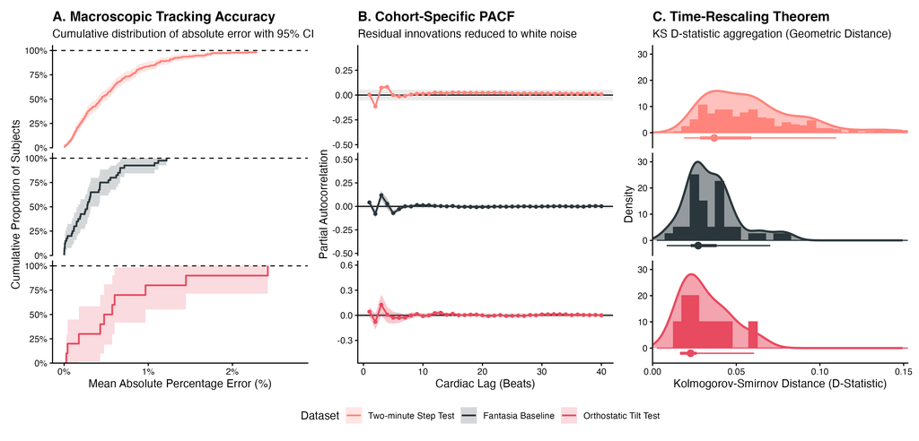

## 3.2 Segregation of autonomic kinetics

A critical theoretical requirement of the proposed model is its ability to blindly segregate rapid vagal dynamics from slower sympathetic modulations without relying on arbitrary, hard-coded frequency boundaries.

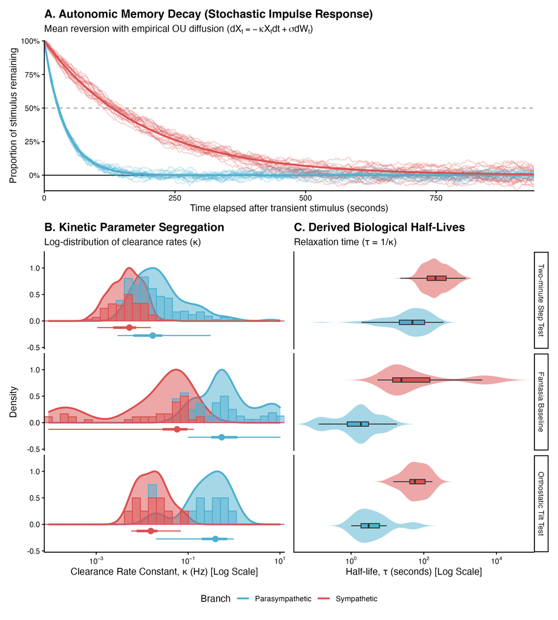

Figure 2: Biological Construct Validity and Kinetic Segregation. (A) Theoretical impulse response function (mean reversion) modeling the autonomic memory decay based on population median parameters. (B) Posterior distributions of the parasympathetic ($\kappa_p$) and sympathetic ($\kappa_s$) kinetic clearance rates across resting, orthostatic, and metabolic states. The model achieves strict biophysical uncoupling without arbitrary frequency bandpass filters. (C) Translation of clearance rates into biological relaxation half-lives ($\tau = 1/\kappa$), validating that the extracted parameters align with the rapid hydrolysis of vagal acetylcholine and the delayed reuptake of sympathetic catecholamines.

## 3.3 Dynamic state reconstruction and phase-space topology

By projecting the estimated parameters back into the temporal domain, the framework provides an instantaneous, beat-to-beat reconstruction of the latent autonomic drives (Figure 3). We visualized this continuous-time tracking across an orthostatic tilt transition and an exercise-to-recovery protocol.

In both paradigms, the SDE state-reconstruction successfully tracked the rapid vagal withdrawal followed by a gradual sympathetic surge. However, projecting these state trajectories geometrically over the thermodynamic potential basin ($U = \frac{1}{2} x^T \Sigma^{-1} x$) reveals the underlying allostatic topology. The transition forms a distinct hysteresis loop; the system is rapidly displaced from its homeostatic minimum ($0,0$) during the onset of the stressor and takes an alternate, metabolically costly path back to equilibrium during recovery.

Statistical comparisons of the stationary covariance topologies confirmed the model’s sensitivity to varying allostatic loads; the sympathetic state variance expanded significantly from resting baseline to maximal metabolic exertion ($\chi^2$ (2) = 43.31, p-value < 0.001). By mapping the covariance matrix, the geometric topology directly visualizes the magnitude of the subject’s allostatic displacement and their subsequent restorative capacity.

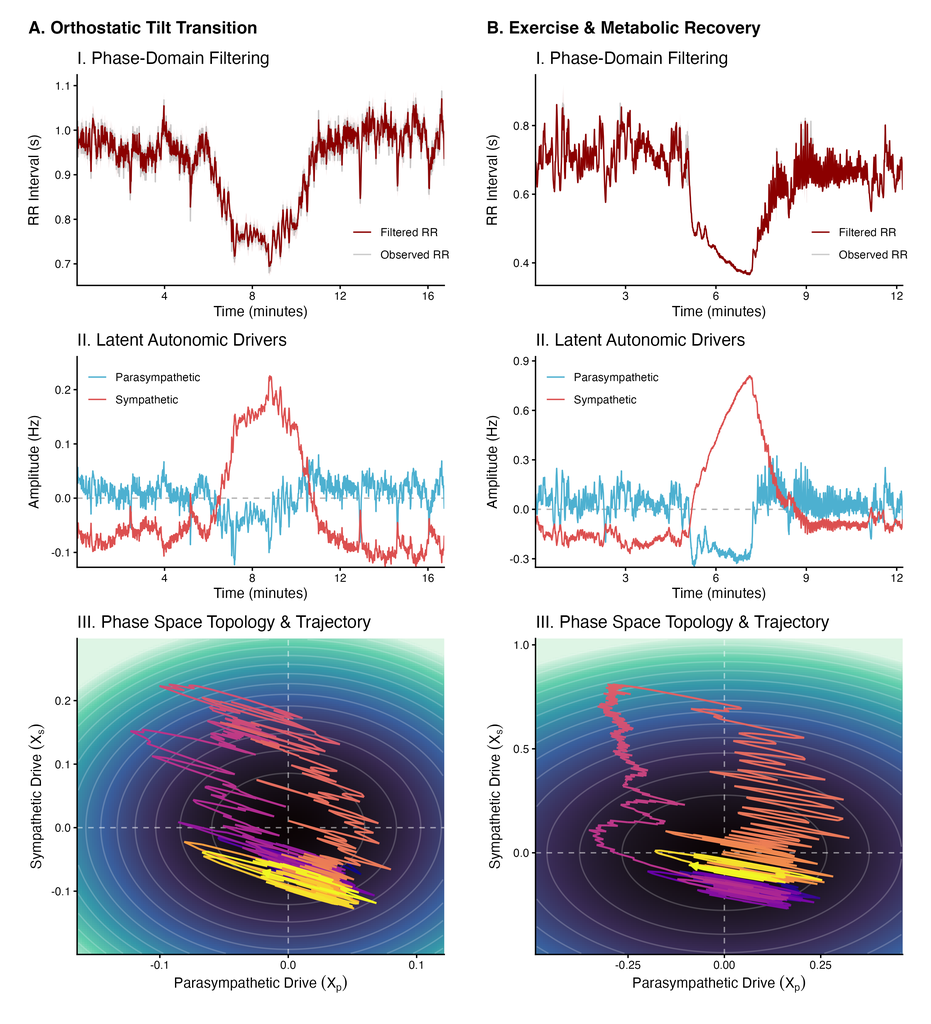

Figure 3: Dynamic Phase-Space Topology and Allostatic Reconstruction. (I-II) Instantaneous, continuous-time tracking of uncoupled latent autonomic drives during an orthostatic transition (A) and exercise-to-recovery protocol (B) alongside the phase-domain implied fit (95% CI). (III) State trajectories geometrically mapped onto the theoretical thermodynamic energy basin ($U = \frac{1}{2} x^T \Sigma^{-1} x$). The resulting hysteresis loops illustrate the allostatic displacement from the homeostatic minimum ($0,0$) and the restorative paths constrained by the estimated stationary covariance.

## 3.4 Overcoming classical time-frequency limitations

Finally, we benchmarked the generative SDE framework against the non-stationary classical gold standard: the Continuous Morlet Wavelet Transform (CWT) moving power spectral density (Figure 4).

In contrast, the proposed SDE framework tracked the structural break instantaneously. By natively estimating the states in the time domain as a continuous stochastic process, the generative model entirely bypasses the traditional time-frequency uncertainty trade-off. This results in zero algorithmic latency and eliminates temporal smearing, allowing for the precise localization of transient autonomic shifts that classical moving-window techniques fail to capture.

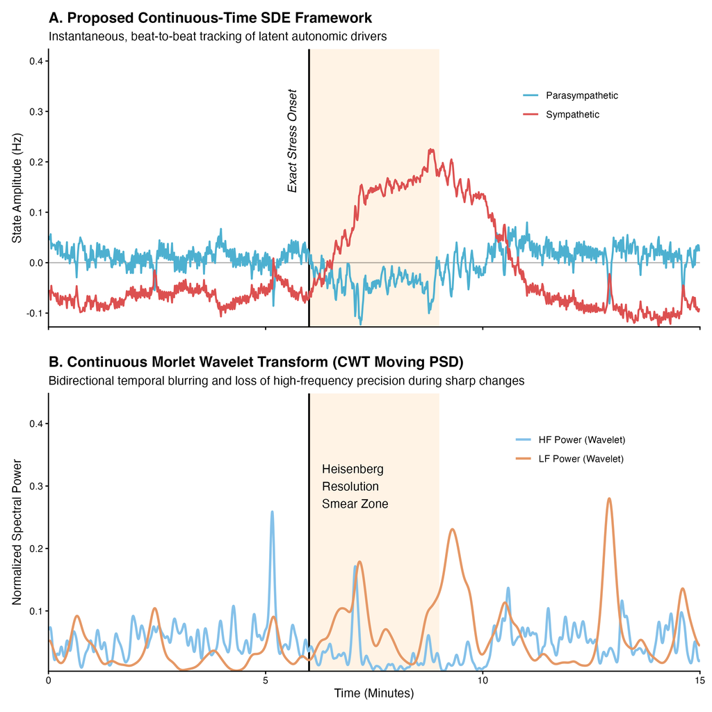

Figure 4: Avoiding the temporal-resolution limitations of traditional spectral methods. (A) The proposed generative SDE framework achieves instantaneous detection of the state shift at the exact onset of orthostatic stress. (B) Benchmarking against the classical Continuous Morlet Wavelet Transform (CWT). The fundamental requirement for temporal windowing in non-stationary spectral analysis introduces a severe “Heisenberg resolution smear zone”, resulting in non-causal bidirectional blurring and a significant delay in localizing the autonomic transition.

# 4 Discussion

## 4.1 Mathematical and biological architecture

The empirical performance and consistency of the SPARK framework demonstrate the successful resolution of long-standing estimation bottlenecks in non-invasive cardiac autonomic monitoring. The operational capability of the SPARK model is fundamentally derived from its structural coordinate inversion, swapping an intractable time-domain first-passage problem for a conditionally Gaussian phase-domain observation. By deploying analytical marginalization to profile out baseline pacing and global volatility prior to likelihood estimation, the framework secures geometric stability against degenerate topologies that typically plague unconstrained biological state-spaces (Candia-Rivera, Vico Fallani, and Chavez 2025). Crucially, this isomorphic inversion natively resolves the physiological phenomenon of vagal gating, wherein high parasympathetic tone actively amplifies macroscopic interval variance. While the latent SDE operates under strict homoskedastic volatility to preserve linear-Gaussian tractability, projecting these dynamics into the time domain recovers heteroskedastic variance. Because the variance of an Inverse Gaussian first-passage time scales inversely with the cube of the underlying phase drift, parasympathetic activation guarantees an exponential expansion in macroscopic variability (for reference, see the “Emergent macroscopic heteroskedasticity via first-passage time” section in the supplementary material). Consequently, state-dependent nonlinear variance emerges naturally from a homoskedastic linear framework, eliminating the reliance on unstable, nonlinear approximations (e.g., Taylor-series expansions or sigma-point matrices) to capture observation noise (Amor, Rasool, and Bouaynaya 2018; Ding and Wen 2024).

The biological grounding of this framework represents a significant departure from, and a mathematical advancement over, historical point-process formulations in heart rate variability analysis. Traditional point-process models frequently rely on generalized linear models or autoregressive history structures to capture the temporal dependencies of successive inter-beat intervals (Barbieri et al. 2005; Chen et al. 2012). While computationally efficient, generalized linear models are inherently phenomenological, mapping statistical associations across discrete events without establishing an explicit, continuous-time link to the underlying biophysical processes of the sinoatrial node (Kashou, Basit, and Chhabra 2017). Conversely, existing state-space point-process formulations that do incorporate the biophysical principles of the Integral Pulse Frequency Modulation framework typically attempt to solve the system equations directly in the time domain (Candia-Rivera et al. 2021). This choice forces the application of nonlinear filtering schemes, such as extended or unscented Kalman filters, which evaluate discrete time steps through Euler-Maruyama approximations or deterministic sigma-point matrices (Ding and Wen 2024; Amor, Rasool, and Bouaynaya 2018). These formulations introduce systematic cumulative errors when applied to highly non-stationary data, as they fail to preserve the true continuous-time dynamics of the underlying differential equations across uneven sampling intervals (Ding and Wen 2024; Li, Kenney, and Gu 2026). The proposed framework addresses this limitation by augmenting the state vector to track both the instantaneous values of the parasympathetic and sympathetic Ornstein-Uhlenbeck processes and their running integrals. Because the underlying stochastic differential equations remain linear, the discrete-time transitions across variable inter-beat durations are solved analytically via the matrix exponential (for reference, see the “Continuous-discrete state-space formulation via matrix exponential” section in the supplementary material). This execution ensures that the model evaluates the continuous-time trajectory of the latent neural drives, while the instantaneous resetting of the integral states to zero upon event registration mirrors the biophysical resetting of the cardiac pacemaker cells after reaching the depolarization threshold.

## 4.2 Empirical validation and spectral anchoring

The structural robustness of this architecture is empirically confirmed by the performance of its validation pipeline across multiple independent datasets representing distinct physiological provocations. The application of the time-rescaling theorem provides a distribution-free diagnostic of goodness-of-fit, providing compelling evidence that the standardized innovations derived from the phase-domain filtering loop conform to an independent and identically distributed standard normal sequence (Brown et al. 2002; Barbieri et al. 2005). The empirical observation that the cumulative distribution functions of these innovations remain within the calculated Kolmogorov-Smirnov confidence bounds across the Fantasia, orthostatic tilt, and exercise recovery records confirms the validity of the linear-Gaussian phase-domain transformation. A primary methodological strength of this validation pipeline is the integration of the Continuous Wavelet Transform using a localized Morlet wavelet for spectral anchoring. Traditional implementations of Parseval’s theorem in state-space modeling typically rely on the Fast Fourier Transform or Welch’s periodogram to determine the baseline energy distribution of the signal. These non-parametric spectral estimators impose an unyielding assumption of global signal stationarity, causing transient autonomic fluctuations to be smeared across the frequency spectrum and leading to systematic biases in the initialization parameters (Adamczyk and Polak 2025; Bozhokin et al. 2025). By projecting the continuous interpolated cardiac rate into a joint time-frequency space, the Morlet wavelet transform isolates localized, non-stationary energy bursts without distributing their variance across unrelated frequency scales (Gruszecki et al. 2023; Zhuravlev et al. 2025). The subsequent integration of the global wavelet spectrum, adjusted appropriately by the scale differential to account for logarithmic frequency discretization, yields a robust, unconfounded empirical power ratio that stabilizes the maximum a posteriori estimation loop even during highly non-stationary physiological transitions.

## 4.3 Theoretical implications for autonomic thermodynamics

Transitioning heart rate variability analysis from phenomenological signal processing to a generative continuous-time stochastic differential equation framework provides a mathematical foundation for evaluating cardiac regulation through the lens of non-equilibrium statistical mechanics. By embedding latent sympathetic and parasympathetic modulations within a geometric phase space, the proposed model allows researchers to treat the autonomic nervous system as an open, dissipative dynamical system operating away from thermodynamic equilibrium.

Historically, nonlinear cardiovascular physics has evaluated autonomic regulation solely through the geometry of output trajectories (e.g., attractor reconstruction or approximate entropy) (Camm et al. 1996; Shaffer and Ginsberg 2017). In contrast, the continuous parameters extracted by our dual-filter architecture directly identify the governing operators of the underlying biological oscillator itself. The independent Ornstein-Uhlenbeck pathways map the continuous neural states within a quadratic potential energy basin, where the clearance rates ($\kappa_p, \kappa_s$) functionally define the homeostatic generalized restoring forces.

This explicit formulation opens a direct computational pathway for quantifying allostatic load via stochastic entropy production ($\Delta S_{tot}$) and non-equilibrium fluctuation theorems. Because the asymmetric kinetic rates govern the non-conservative transitions observed during stress and recovery, the area enclosed by the phase-space hysteresis loops serves as a direct indicator of broken time-reversal symmetry, a hallmark of living, adaptive systems. The metabolic and neurological cost expended by the organism to maintain chronotropic stability can thus be modeled as the continuous entropy production rate required to sustain a non-equilibrium steady state against environmental perturbations.

Furthermore, preserving the continuous-time trajectories of the latent states allows for the spatial analysis of autonomic flexibility. The two-dimensional geometric scatter of the latent states can be evaluated for phase-space ergodicity, while the vector cross-product of the trajectories quantifies the enclosed area of the physiological hysteresis loop (Figueiredo et al. 2024). Finally, the continuous monitoring of the kinetic clearance parameters may allow for the detection of critical slowing down, a phenomenon in dynamical systems where the energy basin flattens prior to systemic failure, potentially serving as an early-warning biomarker for autonomic collapse (Tirabassi 2024). While the empirical clinical validation of these thermodynamic biomarkers remains a subject for future cohort studies, the mathematical architecture presented here provides the necessary foundation to extract them.

## 4.4 Biophysical system identification

The development of this generative architecture has direct implications for cardiac autonomic research, shifting the clinical and physiological monitoring paradigm from descriptive signal processing to explicit biophysical system identification. For decades, the field of heart rate variability has relied on statistical descriptions of surface electrocardiographic data, treating the output metrics as direct indicators of autonomic tone (S. Liu, Cui, and Chen 2025). However, classical spectral parameters, particularly the low-frequency power component, represent a heavily confounded amalgamation of sympathetic efferent traffic, vagal modulation, and mechanical baroreflex feedback loops, making absolute physiological interpretation impossible (Moak et al. 2007; S. Liu, Cui, and Chen 2025). The proposed framework alters this paradigm by executing a formal inversion that isolates clean, uncoupled, and physically interpretable proxies of the latent autonomic drivers operating directly on the chronotropic properties of the sinoatrial node. Rather than providing arbitrary variance ratios, the model extracts explicit physical parameters, specifically the distinct parasympathetic and sympathetic clearance constants and their derived biological relaxation half-lives. These constants map directly to known cellular mechanisms, reflecting the kinetic separation between the rapid, immediate hydrolysis of acetylcholine within the synaptic cleft and the slow, second-messenger G-protein coupled cascades governing norepinephrine reuptake and diffusion (Varzideh et al. 2026; Maltsev et al. 2023). By mapping the continuous-time trajectories of these uncoupled states, researchers can monitor the instantaneous, beat-to-beat balance of the two autonomic branches during complex physical transitions, providing a non-invasive digital proxy of the sinoatrial node potential landscape.

## 4.5 Systemic and operational limitations

While the proposed framework demonstrates high consistency and robust tracking across validation datasets, we identify several systemic constraints that bound its immediate clinical deployment. The primary theoretical limitation stems from our reliance on spectral identity constraints to fix the latent neural power ratio. Although utilizing the non-stationary Morlet wavelet transform eliminates the restrictive assumption of global signal stationarity, partitioning the independent autonomic drives based on traditional low-frequency and high-frequency boundaries remains a structural simplification required to maintain parameter identifiability from univariate data. However, this assumption does not account for known physiological conditions where the operational frequencies of the two branches overlap. During periods of severe orthostatic stress or high-exertion metabolic exercise, sympathetic modulations can accelerate into the high-frequency domain, while vagal feedback loops can slow into the low-frequency band, potentially causing frequency blending or parameter misallocation within the model (S. Liu, Cui, and Chen 2025; Menuet et al. 2025). Furthermore, the empirical evaluation of this framework was restricted to historical research datasets compiled exclusively from healthy cohorts. Consequently, the numerical stability, parameter convergence, and structural assumptions of the model remain unverified in clinical populations characterized by advanced cardiovascular pathologies, such as diabetic autonomic neuropathy, severe heart failure, or intrinsic sinus node dysfunction, where the biophysical assumptions of the core Integral Pulse Frequency Modulation model may be compromised or altered by structural tissue remodeling (Kashou, Basit, and Chhabra 2017; Braffett et al. 2025; Talishinsky, Ajijola, and Khalsa 2025).

This single-stream formulation introduces further operational limitations, as the framework lacks concurrent multi-stream physiological inputs, omitting explicit couplings for respiration and continuous blood pressure. In the current implementation, respiratory sinus arrhythmia is captured passively as an oscillatory component within the parasympathetic state vector, rather than being driven explicitly by an independent respiratory reference signal (Seidman et al. 2024; Skytioti and Elstad 2022). Similarly, mechanical baroreflex feedback loops are integrated implicitly within the continuous-time state transitions rather than being modeled as an explicit, pressure-driven closed-loop system (S. Liu, Cui, and Chen 2025). The absence of these concurrent physiological streams limits the model’s ability to differentiate between central autonomic commands and peripheral mechanical modulations. Mechanistically, the model is also constrained by the lack of direct validation against invasive physiological gold standards. The reconstructed latent trajectories and their associated clearance constants have not been directly benchmarked against concurrent microneurographic recordings of muscle or cardiac sympathetic nerve activity in humans, nor have they been verified using definitive pharmacological blockade protocols. Without evaluating the model’s response under complete, isolated vagal elimination via atropine administration or complete sympathetic eradication via propranolol infusion, the absolute accuracy of the branch uncoupling mechanism remains a consistent hypothesis derived from literature boundaries rather than an empirically verified physiological certainty (Maki et al. 2024; Maciel et al. 2025; Castiglioni et al. 2026).

## 4.6 Future research perspectives

To transcend these univariate constraints, future iterations of this framework must evolve into multi-sensor data assimilation architectures. Incorporating concurrent, non-invasive continuous signals, such as respiratory chest wall kinematics via inductance plethysmography and peripheral arterial pressure via photoplethysmography, will expand the state-space equations (Tsai et al. 2025; Parikh et al. 2025; Witteveen, Beutel, and Hermeling 2025). This expansion enables the explicit integration of respiratory and baroreflex coupling matrices directly into the continuous-time differential equations, transforming the independent Ornstein-Uhlenbeck processes into a fully coupled multivariate dynamical system. Formally modeling this directional cross-talk will eliminate the necessity for frequency-band coupling constraints, directly resolving the structural threat of spectral blending during extreme physiological transitions and bypassing the need for prior spectral anchoring altogether.

To establish the absolute physiological validity required for widespread clinical adoption, subsequent research must directly benchmark this algorithm against invasive ground-truth recordings. Future clinical trials must deploy concurrent microneurography to capture efferent nerve activity alongside surface electrocardiograms, enabling a point-by-point comparative validation between the inferred latent states and physical nerve traffic. Concurrently, researchers must execute targeted pharmacological blockade protocols. Quantifying parameter trajectories during gradual infusions of autonomic antagonists will definitively verify the model’s uncoupling limits when a single physiological pathway is pharmacologically blocked (Maki et al. 2024; Maciel et al. 2025). Finally, deploying this phase-domain architecture across pathological cohorts, specifically patients with diabetic autonomic neuropathy, atrial fibrillation, or post-infarction remodeling, will ultimately determine its capacity to serve as a predictive diagnostic utility in clinical cardiology.

# 5 Conclusion

This study introduces the SPARK (Stochastic Phase-domain Autonomic Reconstruction Kinetics) framework, addressing key computational limitations in non-invasive cardiac monitoring by aligning the estimation architecture with the continuous-time biophysics of the sinoatrial node. By mapping the nonlinear first-passage time problem into a conditionally linear-Gaussian observation model, the SPARK framework advances heart rate variability analysis beyond phenomenological signal processing toward explicit biophysical system identification. Operating natively in continuous time, the dual-filter architecture extracts isolated kinetic clearance parameters and zero-latency state trajectories that accurately reflect the biological realities of parasympathetic and sympathetic pacing. Furthermore, by embedding the autonomic nervous system within a quantifiable non-equilibrium phase space, this framework establishes a formal computational foundation for analyzing the thermodynamics of human allostatic load. While imminent integration with multi-sensor data assimilation will expand its operational limits, the current architecture proves that continuous-time autonomic reconstruction from discrete cardiac events is mathematically tractable.

## References

Adamczyk, Krzysztof, and Adam G Polak. 2025. “Online Algorithm for Deriving Heart Rate Variability Components and Their Time–Frequency Analysis.” *Applied Sciences* 15 (3): 1210.

Amor, Nesrine, Ghulam Rasool, and Nidhal C Bouaynaya. 2018. “Constrained State Estimation–a Review.” *arXiv Preprint arXiv:1807.03463*.

Arya, Puneet, Mandeep Singh, and MD Singh. 2024. “Multi-Domain Analysis of Ultra-Short-Term HRV for Breathing Pattern Classification in Wearable Health Devices.” *EURASIP Journal on Advances in Signal Processing* 2024 (1): 99.

Barbieri, Riccardo, Eric C Matten, AbdulRasheed A Alabi, and Emery N Brown. 2005. “A Point-Process Model of Human Heartbeat Intervals: New Definitions of Heart Rate and Heart Rate Variability.” *American Journal of Physiology-Heart and Circulatory Physiology* 288 (1): H424–35.

Bozhokin, Sergey V, Irina B Suslova, AA Riabokon, and TD Shokhin. 2025. “Heart Rate Turbulence: Wavelet Analysis of Frequency Modulated Signals.” In *BIOSTEC (1)*, 1038–45.

Braffett, Barbara H, Laure El Ghormli, Catherine Martin, Neil H White, Irl B Hirsch, Anne Bantle, Anders Carlson, et al. 2025. “Cardiovascular Autonomic Neuropathy Defined by Indices of Heart Rate Variability Is Associated with Cardiovascular Disease: A Longitudinal Cohort Study of Participants with Type 1 Diabetes.” *Cardiovascular Diabetology* 24 (1): 334.

Brown, Emery N, Riccardo Barbieri, Valérie Ventura, Robert E Kass, and Loren M Frank. 2002. “The Time-Rescaling Theorem and Its Application to Neural Spike Train Data Analysis.” *Neural Computation* 14 (2): 325–46.

Camm, A John, Marek Malik, J Thomas Bigger, Günter Breithardt, Sergio Cerutti, Richard J Cohen, Philippe Coumel, et al. 1996. “Heart Rate Variability: Standards of Measurement, Physiological Interpretation and Clinical Use. Task Force of the European Society of Cardiology and the North American Society of Pacing and Electrophysiology.” *Circulation* 93 (5): 1043–65.

Candia-Rivera, Diego, Vincenzo Catrambone, Riccardo Barbieri, and Gaetano Valenza. 2021. “Integral Pulse Frequency Modulation Model Driven by Sympathovagal Dynamics: Synthetic Vs. Real Heart Rate Variability.” *Biomedical Signal Processing and Control* 68: 102736.

Candia-Rivera, Diego, Fabrizio de Vico Fallani, and Mario Chavez. 2025. “Robust and Time-Resolved Estimation of Cardiac Sympathetic and Parasympathetic Indices.” *Royal Society Open Science* 12 (1).

Castiglioni, Paolo, Luc Quintin, Giampiero Merati, Maurizio Ferrarin, Gianfranco Parati, and Andrea Faini. 2026. “Multiscale Multifractality of Heart Rate Variability: Role of Autonomic Control.” *The European Physical Journal Special Topics*, 1–14.

Castillo-Aguilar, Matı́as, Diego Mabe-Castro, David Medina, and Cristian Núñez-Espinosa. 2025. “Enhancing Cardiovascular Monitoring: A Non-Linear Model for Characterizing RR Interval Fluctuations in Exercise and Recovery.” *Scientific Reports* 15 (1): 8628.

Chen, Zhe, Patrick L Purdon, Emery N Brown, and Riccardo Barbieri. 2012. “A Unified Point Process Probabilistic Framework to Assess Heartbeat Dynamics and Autonomic Cardiovascular Control.” *Frontiers in Physiology* 3: 4.

Ding, Linwang, and Chenglin Wen. 2024. “High-Order Extended Kalman Filter for State Estimation of Nonlinear Systems.” *Symmetry* 16 (5): 617.

Figueiredo, Benjamin Garcia de, Justin M Calabrese, William F Fagan, and Ricardo Martinez-Garcia. 2024. “Ergodicity Shapes Inference in Biological Reactions Driven by a Latent Trajectory.” *arXiv Preprint arXiv:2409.11433*.

Garcı́a Fernández, Jesús, Nasir Ahmad, and Marcel Van Gerven. 2024. “Ornstein–Uhlenbeck Adaptation as a Mechanism for Learning in Brains and Machines.” *Entropy* 26 (12): 1125.

Govil, Aryan, Eric Yao, and Christina R Borao. 2024. “Multi-Dimensional Framework for EEG Signal Processing and Denoising Through Tensor-Based Architecture.” *arXiv Preprint arXiv:2401.05589*.

Gruszecki, Marcin, Damian Kaufmann, Michał Świątczak, Krzysztof Młodziński, J Patrick Neary, Jyotpal Singh, Jacek Rumiński, and Ludmiła Daniłowicz-Szymanowicz. 2023. “Wavelet Transform Analysis Reveals Differences Between Patients with Impaired Left Ventricular Systolic Function and Healthy Individuals.” *medRxiv*, 2023–09.

Heldt, T, MB Oefinger, M Hoshiyama, and RG Mark. 2003. “Circulatory Response to Passive and Active Changes in Posture.” In *Computers in Cardiology, 2003*, 263–66. IEEE.

Hennis, Konstantin, Chiara Piantoni, Martin Biel, Stefanie Fenske, and Christian Wahl-Schott. 2024. “Pacemaker Channels and the Chronotropic Response in Health and Disease.” *Circulation Research* 134 (10): 1348–78.

Hughes, Rachael A, Michael G Kenward, Jonathan AC Sterne, and Kate Tilling. 2017. “Estimation of the Linear Mixed Integrated Ornstein–Uhlenbeck Model.” *Journal of Statistical Computation and Simulation* 87 (8): 1541–58.

Iyengar, Nikhil, CK Peng, Raymond Morin, Ary L Goldberger, and Lewis A Lipsitz. 1996. “Age-Related Alterations in the Fractal Scaling of Cardiac Interbeat Interval Dynamics.” *American Journal of Physiology-Regulatory, Integrative and Comparative Physiology* 271 (4): R1078–84.

Kashou, Anthony H, Hajira Basit, and Lovely Chhabra. 2017. “Physiology, Sinoatrial Node.”

Kim, Jin Woong, Hyeon Seok Seok, and Hangsik Shin. 2021. “Is Ultra-Short-Term Heart Rate Variability Valid in Non-Static Conditions?” *Frontiers in Physiology* 12: 596060.

Li, Shanglun, Toby Kenney, and Hong Gu. 2026. “Factor State Space Modelling of the Ornstein-Uhlenbeck Process with Measurement Error and Its Application.” *arXiv Preprint arXiv:2605.01262*.

Lin, Runwei, and Ying Wang. 2026. “Dynamic Heartbeat Modeling with Recurrent Neural Networks and Inverse Gaussian Point Process.” *arXiv Preprint arXiv:2604.13815*.

Liu, Hongyu, Yuting Cao, and Xuling Su. 2026. “Emerging Regulatory Mechanisms in Sinoatrial Node Automaticity.” *Journal of Cellular and Molecular Medicine* 30 (4): e71058.

Liu, Shujuan, Yunyi Cui, and Meihong Chen. 2025. “Heart Rate Variability: A Multidimensional Perspective from Physiological Marker to Brain-Heart Axis Disorders Prediction.” *Frontiers in Cardiovascular Medicine* 12: 1630668.

Maciel, Benedito Carlos, Lourenço Gallo-Jr, André Schmidt, and José Antonio Marin-Neto. 2025. “I-Avaliação Da Função Autonômica Cardiovascular Em Indivı́duos Saudáveis.” *Arquivos Brasileiros de Cardiologia* 122 (12): e20250111.

Maki, Katherine A, Madison P Goodyke, Kendra Rasmussen, and Ulf G Bronas. 2024. “An Integrative Literature Review of Heart Rate Variability Measures to Determine Autonomic Nervous System Responsiveness Using Pharmacological Manipulation.” *Journal of Cardiovascular Nursing* 39 (1): 58–78.

Maltsev, Alexander V, Michael D Stern, Edward G Lakatta, and Victor A Maltsev. 2023. “A Novel Conceptual Model of Heart Rate Autonomic Modulation Based on a Small-World Modular Structure of the Sinoatrial Node.” *Frontiers in Physiology* 14: 1276023.

Menuet, Clément, Alona Ben-Tal, Ambre Linossier, Andrew M Allen, Benedito H Machado, Davi JA Moraes, David GS Farmer, et al. 2025. “Redefining Respiratory Sinus Arrhythmia as Respiratory Heart Rate Variability: An International Expert Recommendation for Terminological Clarity.” *Nature Reviews Cardiology* 22 (12): 978–84.

Moak, Jeffrey P, David S Goldstein, Basil A Eldadah, Ahmed Saleem, Courtney Holmes, Sandra Pechnik, and Yehonatan Sharabi. 2007. “Supine Low-Frequency Power of Heart Rate Variability Reflects Baroreflex Function, Not Cardiac Sympathetic Innervation.” *Heart Rhythm* 4 (12): 1523–29.

Parikh, Ankit, Gwyn Lewis, Hamid GholamHosseini, Usman Rashid, David Rice, and Faisal Almesfer. 2025. “Evaluation of in-Ear and Fingertip-Based Photoplethysmography Sensors for Measuring Cardiac Vagal Tone Relevant Heart Rate Variability Parameters.” *Sensors* 25 (5): 1485.

Rahman, Saifur, Radhagayathri Udhayakumar, David Kaplan, Brendan McCarthy, Tye Dawood, Nicholas Mellor, Alexander Senior, Vaughan G Macefield, Dilpreet Buxi, and Chandan Karmakar. 2025. “Photoplethysmography as a Noninvasive Surrogate for Microneurography in Measuring Stress-Induced Sympathetic Nervous Activation—a Machine Learning Approach.” *Computers in Biology and Medicine* 185: 109522.

Reith-Braun, Marcel, Florian Pfaff, Jakob Thummy, and Uwe D Hanebeck. 2023. “Approximate First-Passage Time Distributions for Gaussian Motion and Transportation Models.” In *2023 26th International Conference on Information Fusion (FUSION)*, 1–8. IEEE.

Rosas, Fernando E, Diego Candia-Rivera, Andrea I Luppi, Yike Guo, and Pedro AM Mediano. 2024. “Bayesian at Heart: Towards Autonomic Outflow Estimation via Generative State-Space Modelling of Heart Rate Dynamics.” *Computers in Biology and Medicine* 170: 107857.

Särkkä, Simo, and Ángel F Garcı́a-Fernández. 2020. “Temporal Parallelization of Bayesian Smoothers.” *IEEE Transactions on Automatic Control* 66 (1): 299–306.

Saul, J Philip, and Gaetano Valenza. 2021. “Heart Rate Variability and the Dawn of Complex Physiological Signal Analysis: Methodological and Clinical Perspectives.” *Philosophical Transactions of the Royal Society A: Mathematical, Physical and Engineering Sciences* 379 (2212).

Seidman, Andrew J, Lauren M Bylsma, Xiao Yang, J Richard Jennings, Charles J George, and Maria Kovacs. 2024. “Long-Term Stability of Respiratory Sinus Arrhythmia Among Adults with and Without a History of Depression.” *Psychophysiology* 61 (1): e14427.

Shaffer, Fred, and Jay P Ginsberg. 2017. “An Overview of Heart Rate Variability Metrics and Norms.” *Frontiers in Public Health* 5: 290215.

Skytioti, Maria, and Maja Elstad. 2022. “Respiratory Sinus Arrhythmia Is Mainly Driven by Central Feedforward Mechanisms in Healthy Humans.” *Frontiers in Physiology* 13: 768465.

Talishinsky, Aleksandr, Olujimi A Ajijola, and Sahib S Khalsa. 2025. “Autonomic Imbalance in Cardiomyopathy and Heart Failure: From Neurobiology to Precision Neuromodulation.” *Current Cardiology Reports* 27 (1): 144.

Tirabassi, Giulio. 2024. “Linear Theory of the Spatial Signatures of Critical Slowing Down.” *Physical Review Research* 6 (2): 023228.

Tsai, Ying-Ying, Yu-Jie Chen, Yen-Feng Lin, Fan-Chi Hsiao, Ching-Han Hsu, and Lun-De Liao. 2025. “Photoplethysmography-Based HRV Analysis and Machine Learning for Real-Time Stress Quantification in Mental Health Applications.” *APL Bioengineering* 9 (2).

Varzideh, Fahimeh, Stanislovas S Jankauskas, Pasquale Mone, Urna Kansakar, and Gaetano Santulli. 2026. “Autonomic Neurotransmission in Cardiovascular Regulation and Pathophysiology.” *Frontiers in Neuroscience* 19: 1739330.

Verma, Nishant, Bruce Knudsen, Aaron Gholston, Aaron Skubal, Stephan Blanz, Megan Settell, Jennifer Frank, James Trevathan, and Kip Ludwig. 2023. “Microneurography as a Minimally Invasive Method to Assess Target Engagement During Neuromodulation.” *Journal of Neural Engineering* 20 (2): 026036.

Witteveen, Jolanda, Fabian Beutel, and Evelien Hermeling. 2025. “Toward Ambulatory Baroreflex Sensitivity: Comparison Between Indices of Arterial Line and Photoplethysmography in Male Volunteers.” *JMIR Cardio* 9: e54771.

Yang, Pei-Chi, Adam Rose, Kevin R DeMarco, John RD Dawson, Yanxiao Han, Mao-Tsuen Jeng, Robert D Harvey, et al. 2023. “A Multiscale Predictive Digital Twin for Neurocardiac Modulation.” *The Journal of Physiology* 601 (17): 3789–3812.

Zhuravlev, Maksim O, Anastasiya E Runnova, Sergei A Mironov, Julia A Zhuravleva, and Anton R Kiselev. 2025. “Continuous Estimation of Heart Rate Variability from Electrocardiogram and Photoplethysmogram Signals with Oscillatory Wavelet Pattern Method.” *Sensors* 25 (17): 5455.